# 3.Pynar Editörde Oturum Açma

Editörün sağ üst köşesinde bulunan avatar ikonuna tıklayın.

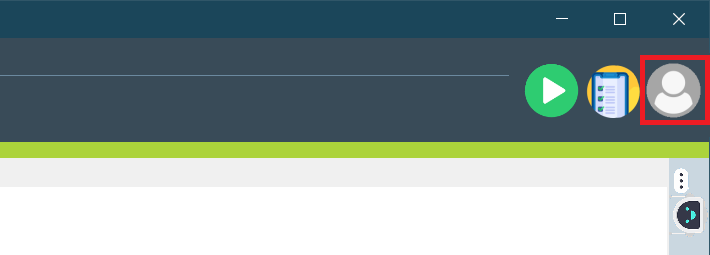

3

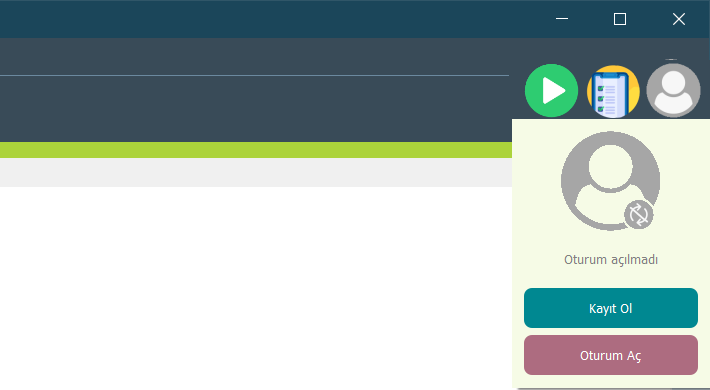

Hesabınızın bilgilerini girdikten sonra Giriş yap düğmesine tıklayın. Şifreyi göster yazısına tıkladığınızda geçici olarak şifreniz görünür olup kaybolmaktadır.

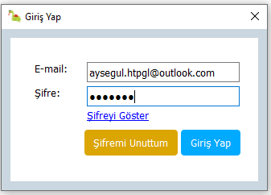

5

Eğer şifrenizi hatırlamazsanız şifremi unuttum düğmesine tıklayarak şifre yenileme işlemlerinize e-postanıza gelecek bağlantı aracılığı ile devam edebilirsiniz.

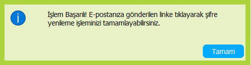

6

Giriş işlemi tamamlandıktan sonra sağ üst köşede isminizin ve soyisminizin baş harflerini adınıza tanımlanan sınav ve sınav sonuçlarınızı görebilirsiniz.

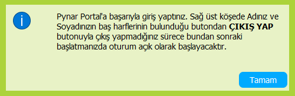

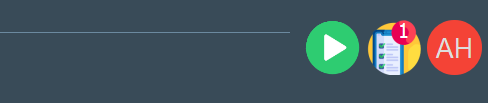

## 3.1 www.pynar.org portalına kayıt olma

http://www.pynar.org/portal/ adresine gidin. Öğrenci Girişini seçin.

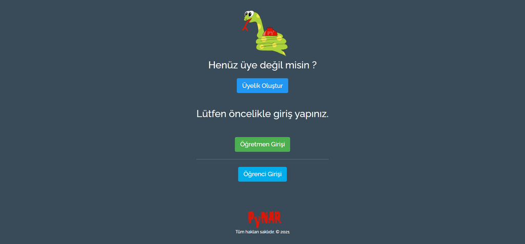

image

'Bir hesabın yok mu?' seçeneğini seçerek öğrenci kayıt formuna gidin.

[figure not shown]

image

Bilgilerinizi doldurduktan sonra 'Kayıt Ol' butonuna tıklayın.

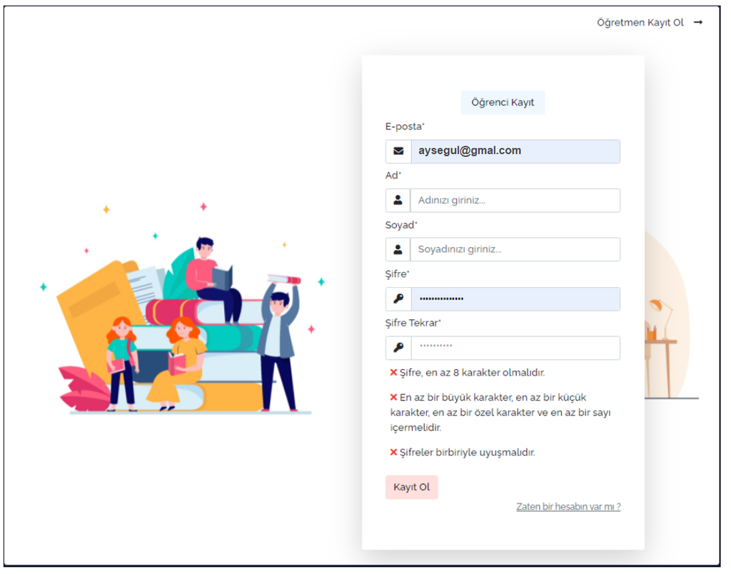

image

## 3.2 E-posta doğrulama

Kayıt olurken kullandığınız E-posta adresine gelen onay postasını açarak kaydı tamamlayın.

[figure not shown]

image

Kaydınız tamamlandıktan sonra http://www.pynar.org/portal/ adresine tekrar gidin ve öğrenci girişini seçin.

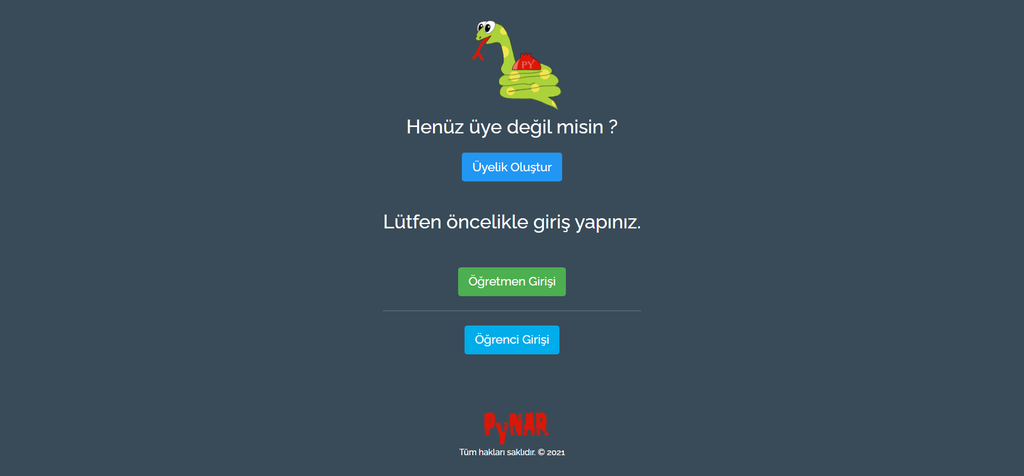

image

Kayıt olurken kullandığınız E-mail adresiniz ve şifreniz ile sisteme giriş yapabilirsiniz.

[figure not shown]

image

## 3.3 Okul ve öğretmen bilgisi düzenleme

Giriş yaptıktan sonra sol menüde bulunan 'Bilgilerim'e tıklayın.

[figure not shown]

image

Okul bilgileriniz kısmının sağ üstünde bulunan düzenle ikonuna tıklayarak bilgilerinizi düzenleyebilirsiniz.

[figure not shown]

image

Bilgilerinizi girdikten sonra 'Güncelle' butonuna tıklayın.

[figure not shown]

image

Bilgileriniz güncellendikten sonra bu şekilde görünecektir.

[figure not shown]

image